# Regression Models Class Project

Yakov Falkovich

Tuesday, September 22, 2015

## Executive summary

The goal of this project is to discover and quantify the effect of transmission type (automatic or manual) on car fuel economy (measured in MPG). A simple model demonstrates that MPG and transmission are in fact connected, more complex models are built by adding highly correlated variables and then narrowing down on the simplest model that explains the most data using ANOVA.

## Exploratory analysis and naive model

The first step of analysis is comparing MPG numbers between manual and automatic cars, the boxplots are shown in figure 1. These shoe clearly that most manuals cars have a much higher MPG result.

Let’s look at a single variable regression for a first approximation of the effect:

```
##              Estimate Std. Error   t value     Pr(>|t|)
## (Intercept) 17.147368   1.124603 15.247492 1.133983e-15
## am           7.244939   1.764422  4.106127 2.850207e-04
```

The average manual car gets 7.245 more miles per gallon compared to an automatic. It’s highly significant, so it’s a good bet that the effect actually exists and isn’t a byproduct of confounders.

## Evaluating possible confounding variables

To simplify, we look at the correlation matrix for MPG and AM in figure 2.  
Variables that have large correlations with both MPG and AM could affect the model significantly. CARB and VS have weak correlations with AM so probably don’t confound it a lot. QSEC and HP also have weak correlations and besides they measure outcomes of the car (speed and power) and not inputs. They should only be meaningful if they represent some exogenous variable (like aerodynamics - if sleeker cars with high QSEC and MPG tend to be automatic), they cannot by themselves be common causes of AM and MPG thus causing spurious correlations. WT, GEAR, DRAT, DISP, CYL have strong correlations with the same sign for AM and MPG, so those variables may have a large effect on the AM-MPG connection and could even reverse it. All of those 5 likely confounders must be tested by including them in models.

## Model generation and comparison

Let’s compare the simplest model, the one with the 5 likely confounders and one with all 9 possible confounders.

```r
fit1=lm(mpg~am,data=mtcars)
fit2=lm(mpg~am+wt+disp+cyl+gear+drat,data=mtcars)
fit3=lm(mpg~.,data=mtcars)
print(anova(fit1,fit2,fit3),signif.stars=F)
```

```
## Analysis of Variance Table
##
## Model 1: mpg ~ am
## Model 2: mpg ~ am + wt + disp + cyl + gear + drat
## Model 3: mpg ~ cyl + disp + hp + drat + wt + qsec + vs + am + gear + carb
##   Res.Df    RSS Df Sum of Sq       F    Pr(>F)
## 1     30 720.90
## 2     25 182.10  5    538.80 15.3426 2.127e-06
## 3     21 147.49  4     34.61  1.2318    0.3276
```

Clearly the extra covariates in the third model add no explanatory power. A closer look at the model including the 5 covariates (figure 3) shows that only weight and cylinders are significant.

We include some interaction effects to find the best model:

```
## Analysis of Variance Table
##
## Model 1: mpg ~ am * wt
## Model 2: mpg ~ am * wt + cyl
## Model 3: mpg ~ am * wt * cyl
##   Res.Df    RSS Df Sum of Sq      F   Pr(>F)
## 1     28 188.01
## 2     27 138.51  1    49.502 9.2457 0.005633
## 3     24 128.50  3    10.008 0.6230 0.607012
```

## Diagnostics

A few car show up as consistent outliers (Fiat 128, Toyota Corolla, Datsun), we can estimate the effect of excluding them from the data that we model.

```r
round(dfbetas(fit5),3)[c(3,18,20),]
```

```
##                (Intercept)     am     wt    cyl  am:wt
## Datsun 710          -0.086 -0.065 -0.144  0.260 -0.010
## Fiat 128             0.102  0.249  0.170 -0.308 -0.150
## Toyota Corolla      -0.021  0.574 -0.035  0.063 -0.559
```

```r
round(hatvalues(fit5),3)[c(3,18,20)]
```

```
##     Datsun 710       Fiat 128 Toyota Corolla
##          0.101          0.098          0.150
```

The Toyota and Fiat have positive dfbetas for AM (which itself has a positive coefficient), so excluding them will show a smaller but still significant effect of AM on MPG. Since all three cars have lower influence scores than the average $bar{h_{ii}}=0.156$ their effect on the overall model isn’t large and they should probably not be excluded.

## Conclusion

We have arrived at a model of miles per gallon as a function of transmission type, weight and number of cylinders. The model is significant, powerful (predicting 85% of the variance) and parsimonious (contains no insignificant variables). The residual distribution satisfies the assumptions that linear regression makes, and there aren’t any outliers with outsize influence on the results.

# Appendix - Figures and Charts

## Figure 1: Boxplot of MPGs for automatic and manual cars

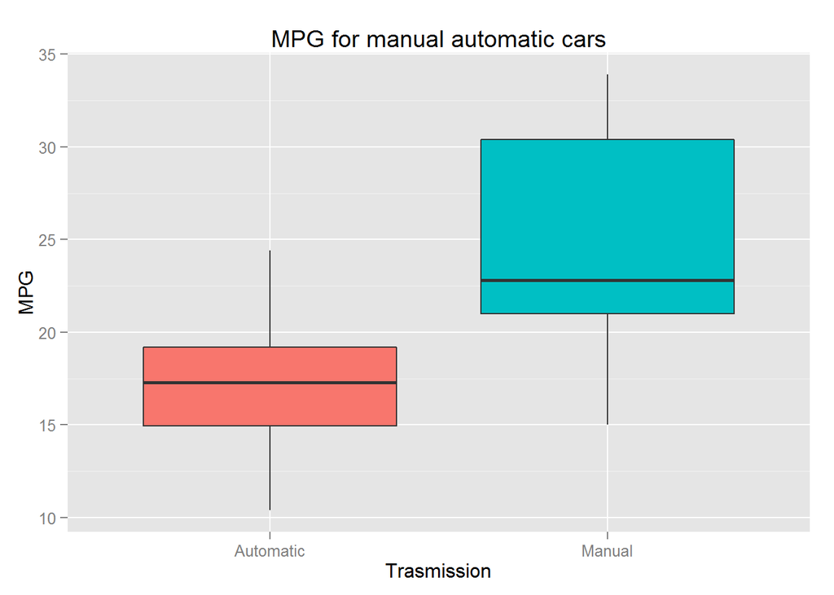

## Figure 2: Heatmap of covariates and correlations

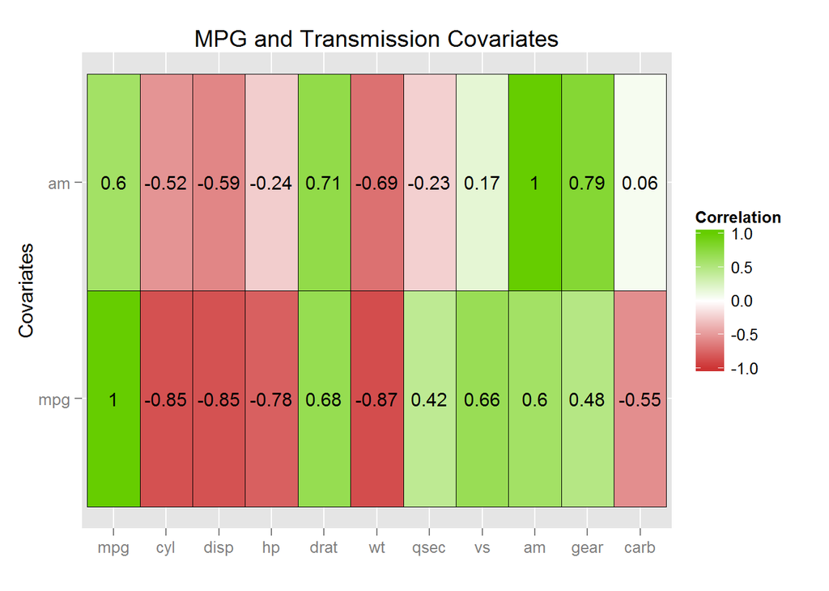

## Figure 3: Fitted regression with 5 covariates

```
##                 Estimate Std. Error    t value     Pr(>|t|)
## (Intercept) 42.849311191 7.74036062  5.5358288 9.380637e-06
## am           1.181575927 1.87872450  0.6289245 5.351034e-01
## wt          -3.425362195 1.22604961 -2.7938202 9.851503e-03
## disp         0.005705375 0.01248138  0.4571109 6.515388e-01
## cyl         -1.740815446 0.65474013 -2.6587884 1.348144e-02
## gear        -1.072365153 1.15316450 -0.9299325 3.612992e-01
## drat         0.331102911 1.61859955  0.2045614 8.395711e-01
```

## Figure 4: Model 5 - 2 covariates and one interaction

```
##
## Call:
## lm(formula = mpg ~ am * wt + cyl, data = mtcars)
##
## Residuals:
##     Min      1Q  Median      3Q     Max
## -3.4621 -1.4913 -0.7879  1.3959  5.3499
##
## Coefficients:
##             Estimate Std. Error t value Pr(>|t|)
## (Intercept)  34.2830     2.7965  12.259 1.52e-12 ***
## am           11.9385     3.8453   3.105  0.00444 **
## wt           -2.3689     0.8244  -2.874  0.00782 **
## cyl          -1.1814     0.3803  -3.106  0.00442 **
## am:wt        -4.1974     1.3115  -3.200  0.00350 **
## ---
## Signif. codes:  0 '***' 0.001 '**' 0.01 '*' 0.05 '.' 0.1 ' ' 1
##
## Residual standard error: 2.265 on 27 degrees of freedom
## Multiple R-squared:  0.877,  Adjusted R-squared:  0.8588
## F-statistic: 48.13 on 4 and 27 DF,  p-value: 6.643e-12
```

## Figure 5: Residual diagnostics for Model 5

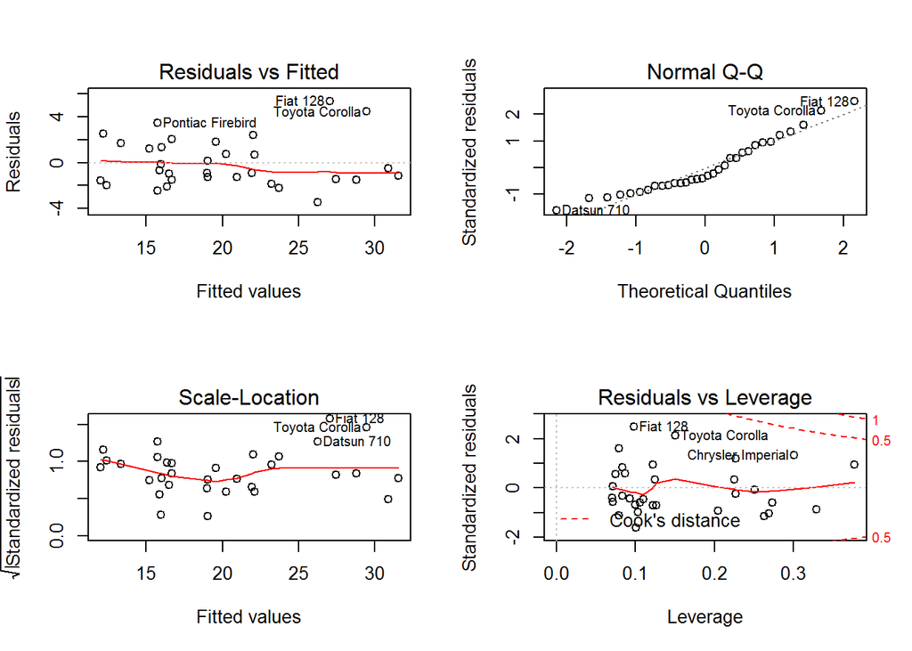